# Homework 2

### 24: Visualizazione GarageArea

```r
visualization_continuos(na.omit(House_prices[,"GarageArea"]), sum_info_h[24],"GarageArea")
```

```
## [[1]]
## [[1]]$GarageArea
## [[1]]$GarageArea$Summary
##    Min. 1st Qu.  Median    Mean 3rd Qu.    Max.
##     0.0   334.5   480.0   473.0   576.0  1418.0
##
## [[1]]$GarageArea$Variance
## [1] 45712.51
##
## [[1]]$GarageArea$Standard_Deviation
## [1] 213.8
##
## [[1]]$GarageArea$Moda
## [[1]]$GarageArea$Moda$Mode
## [1] 0
##
## [[1]]$GarageArea$Moda$Frequency
## [1] 81
```

```
##
## Call:
##  density.default(x = data)
##
## Data: data (1460 obs.);  Bandwidth 'bw' = 37.77
##
##        x                y
##  Min.   :-113.3   Min.   :8.960e-08
##  1st Qu.: 297.8   1st Qu.:1.752e-05
##  Median : 709.0   Median :3.136e-04
##  Mean   : 709.0   Mean   :6.074e-04
##  3rd Qu.:1120.2   3rd Qu.:1.028e-03
##  Max.   :1531.3   Max.   :2.465e-03
```

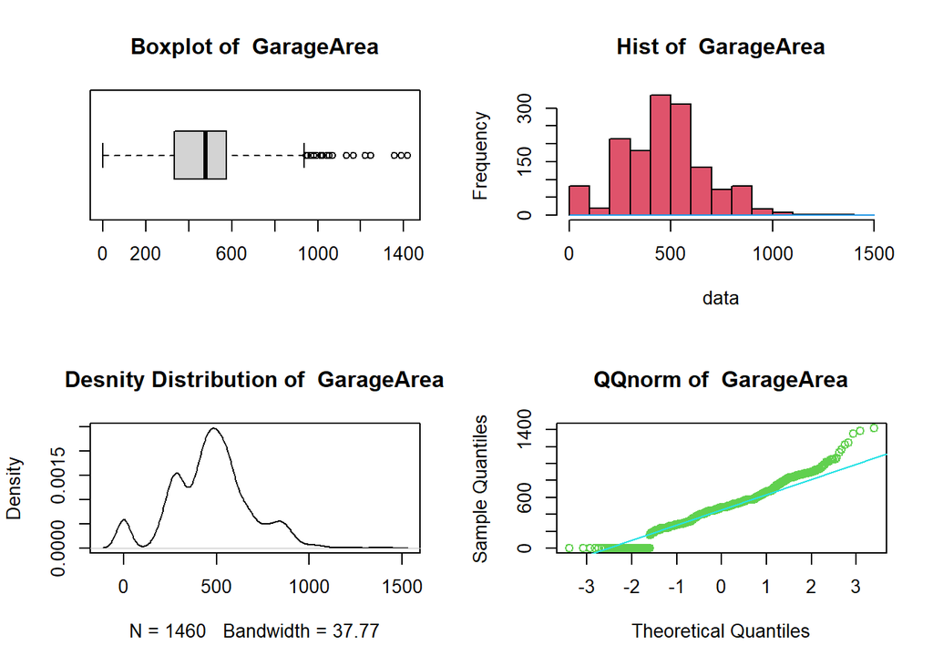

Possiamo dedurre che la distribuzione è positivamente asimetrica e che la maggior parte degli garage sono di area compresa tra 334.5 e 576.0 piedi^2, essendo rispettivamente il 1° e il 3° quantile e con maggior densita alineati alla retta qq della norma. Rimangono ancora degli outlier ## Rimozione

```r
rm_outlier_data = rm_oultiers(na.omit(House_prices[,"GarageArea"]),.95)
visualization_continuos(rm_outlier_data, univariate_analysis(rm_outlier_data,"GarageArea"),"GarageArea")
```

```
## $GarageArea
## $GarageArea$Summary
##    Min. 1st Qu.  Median    Mean 3rd Qu.    Max.
##   160.0   367.0   480.0   486.2   576.0   890.0
##
## $GarageArea$Variance
## [1] 27180.41
##
## $GarageArea$Standard_Deviation
## [1] 164.86
##
## $GarageArea$Moda
## $GarageArea$Moda$Mode
## [1] 440
##
## $GarageArea$Moda$Frequency
## [1] 49
```

```
##
## Call:
##  density.default(x = data)
##
## Data: data (1341 obs.);  Bandwidth 'bw' = 33.25
##
##        x                y
##  Min.   : 60.25   Min.   :4.263e-07
##  1st Qu.:292.62   1st Qu.:4.245e-04
##  Median :525.00   Median :8.686e-04
##  Mean   :525.00   Mean   :1.075e-03
##  3rd Qu.:757.38   3rd Qu.:1.691e-03
##  Max.   :989.75   Max.   :2.722e-03
```

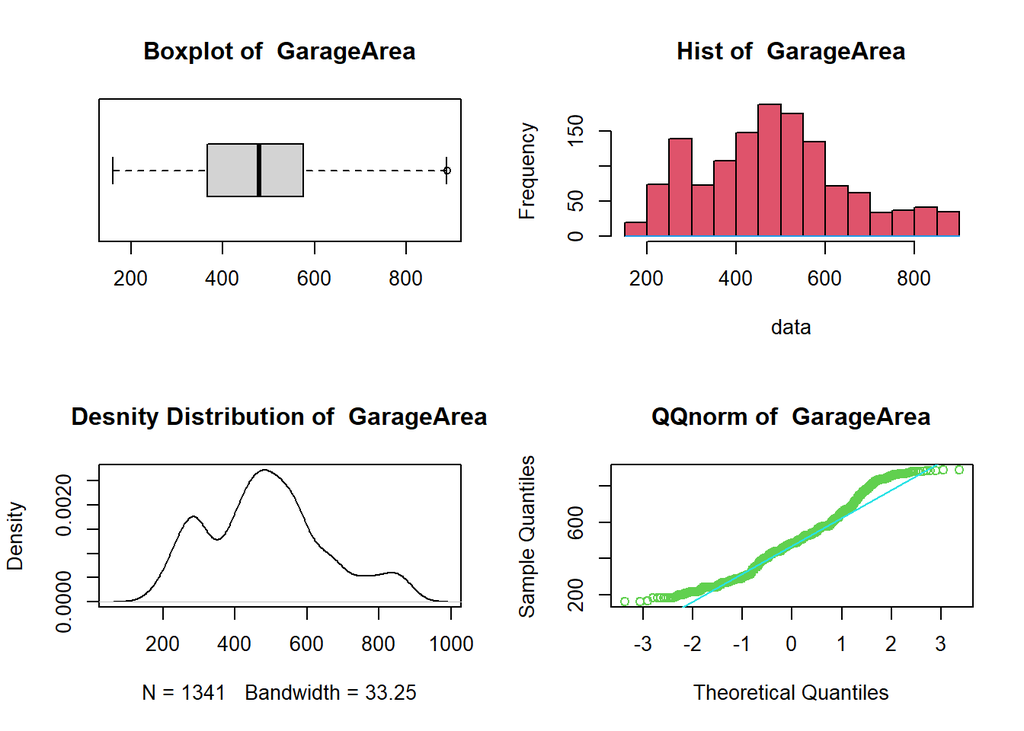

### 25: Visualizazione WoodDeckSF

```r
visualization_continuos(na.omit(House_prices[,"WoodDeckSF"]), sum_info_h[25],"WoodDeckSF")
```

```
## [[1]]
## [[1]]$WoodDeckSF
## [[1]]$WoodDeckSF$Summary
##    Min. 1st Qu.  Median    Mean 3rd Qu.    Max.
##    0.00    0.00    0.00   94.24  168.00  857.00
##
## [[1]]$WoodDeckSF$Variance
## [1] 15709.81
##
## [[1]]$WoodDeckSF$Standard_Deviation
## [1] 125.34
##
## [[1]]$WoodDeckSF$Moda
## [[1]]$WoodDeckSF$Moda$Mode
## [1] 0
##
## [[1]]$WoodDeckSF$Moda$Frequency
## [1] 761
```

```
##
## Call:
##  density.default(x = data)
##
## Data: data (1460 obs.);  Bandwidth 'bw' = 26.27
##
##        x                y
##  Min.   :-78.81   Min.   :1.180e-07
##  1st Qu.:174.85   1st Qu.:2.217e-05
##  Median :428.50   Median :1.736e-04
##  Mean   :428.50   Mean   :9.840e-04
##  3rd Qu.:682.15   3rd Qu.:1.377e-03
##  Max.   :935.81   Max.   :8.060e-03
```

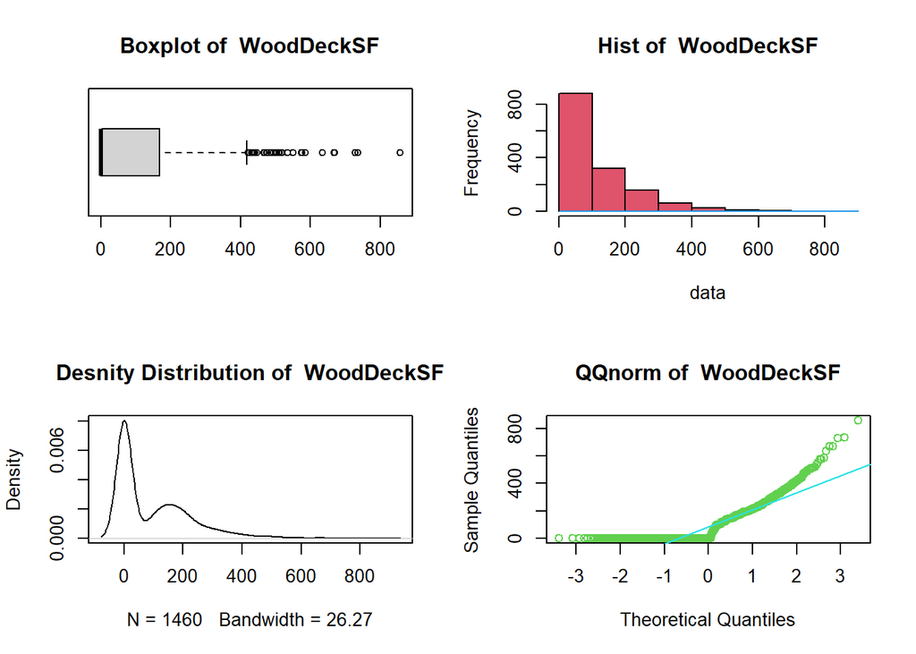

Possiamo dedurre che la distribuzione è positivamente asimetrica. Si puo osservare che l’area del ponte di legno è prelevantemete 0 con 761 occorrenze qundi non costruitto. Per fare un analisi sui ponti di legno costruiti, serve ignorare quelli non ## Rimozione 0

```r
rm_0_data = rm_0(na.omit(House_prices[,"WoodDeckSF"]))
visualization_continuos(rm_0_data, univariate_analysis(rm_0_data,"WoodDeckSF"),"WoodDeckSF")
```

```
## $WoodDeckSF
## $WoodDeckSF$Summary
##    Min. 1st Qu.  Median    Mean 3rd Qu.    Max.
##    12.0   120.0   171.0   196.8   240.0   857.0
##
## $WoodDeckSF$Variance
## [1] 12611.23
##
## $WoodDeckSF$Standard_Deviation
## [1] 112.3
##
## $WoodDeckSF$Moda
## $WoodDeckSF$Moda$Mode
## [1] 192
##
## $WoodDeckSF$Moda$Frequency
## [1] 38
```

```
##
## Call:
##  density.default(x = data)
##
## Data: data (699 obs.);   Bandwidth 'bw' = 21.75
##
##        x                y
##  Min.   :-53.24   Min.   :3.000e-07
##  1st Qu.:190.63   1st Qu.:4.159e-05
##  Median :434.50   Median :2.577e-04
##  Mean   :434.50   Mean   :1.024e-03
##  3rd Qu.:678.37   3rd Qu.:1.424e-03
##  Max.   :922.24   Max.   :4.913e-03
```

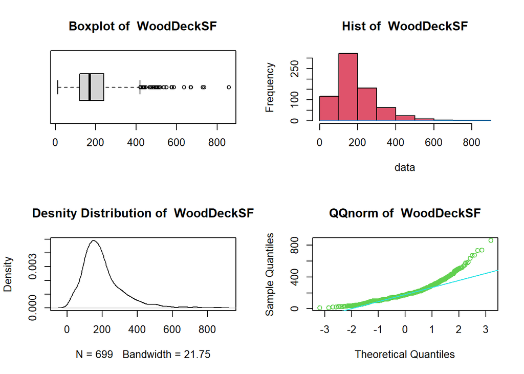

Possiamo dedurre che la distribuzione è positivamente asimetrica e che la maggior parte dei ponte di legno sono di area compresa tra 120.0 e 240.0 piedi^2, essendo rispettivamente il 1° e il 3° quantile e con maggior densita alineati alla retta qq della norma. Rimangono ancora degli outlier ## Rimozione

```r
rm_outlier_data = rm_oultiers(rm_0_data,.95)
visualization_continuos(rm_outlier_data, univariate_analysis(rm_outlier_data,"GarageArea"),"GarageArea")
```

```
## $GarageArea
## $GarageArea$Summary
##    Min. 1st Qu.  Median    Mean 3rd Qu.    Max.
##    12.0   120.0   168.0   180.5   224.0   416.0
##
## $GarageArea$Variance
## [1] 7000.37
##
## $GarageArea$Standard_Deviation
## [1] 83.67
##
## $GarageArea$Moda
## $GarageArea$Moda$Mode
## [1] 192
##
## $GarageArea$Moda$Frequency
## [1] 38
```

```
##
## Call:
##  density.default(x = data)
##
## Data: data (666 obs.);   Bandwidth 'bw' = 19.03
##
##        x                y
##  Min.   :-45.09   Min.   :9.290e-07
##  1st Qu.: 84.45   1st Qu.:4.785e-04
##  Median :214.00   Median :1.407e-03
##  Mean   :214.00   Mean   :1.928e-03
##  3rd Qu.:343.55   3rd Qu.:3.284e-03
##  Max.   :473.09   Max.   :5.225e-03
```

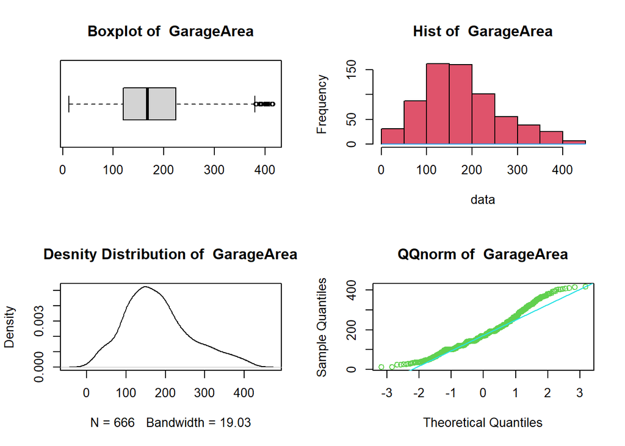

### 26: Visualizazione OpenPorchSF

```r
visualization_continuos(na.omit(House_prices[,"OpenPorchSF"]), sum_info_h[26],"OpenPorchSF")
```

```
## [[1]]
## [[1]]$OpenPorchSF
## [[1]]$OpenPorchSF$Summary
##    Min. 1st Qu.  Median    Mean 3rd Qu.    Max.
##    0.00    0.00   25.00   46.66   68.00  547.00
##
## [[1]]$OpenPorchSF$Variance
## [1] 4389.86
##
## [[1]]$OpenPorchSF$Standard_Deviation
## [1] 66.26
##
## [[1]]$OpenPorchSF$Moda
## [[1]]$OpenPorchSF$Moda$Mode
## [1] 0
##
## [[1]]$OpenPorchSF$Moda$Frequency
## [1] 656
```

```
##
## Call:
##  density.default(x = data)
##
## Data: data (1460 obs.);  Bandwidth 'bw' = 10.64
##
##        x                y
##  Min.   :-31.91   Min.   :2.300e-08
##  1st Qu.:120.80   1st Qu.:2.790e-05
##  Median :273.50   Median :1.925e-04
##  Mean   :273.50   Mean   :1.635e-03
##  3rd Qu.:426.20   3rd Qu.:1.603e-03
##  Max.   :578.91   Max.   :1.730e-02
```

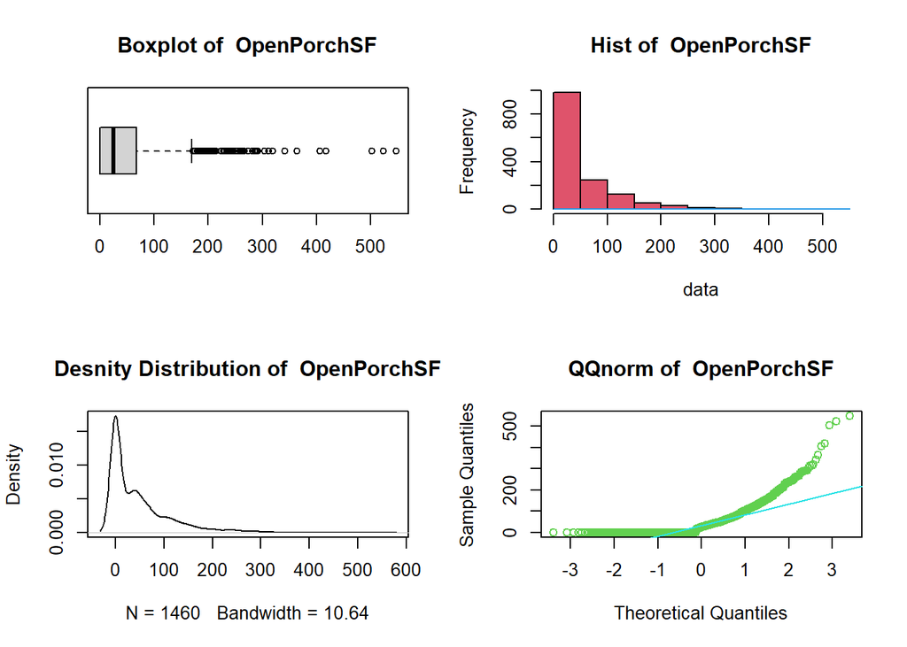

Possiamo dedurre che la distribuzione è positivamente asimetrica. Si puo osservare che l’area del portico aperto è prelevantemete 0 con 656 occorrenze qundi non costruitto. Per fare un analisi sui portico aperti, serve ignorare quelli non ## Rimozione 0

```r
rm_0_data = rm_0(na.omit(House_prices[,"OpenPorchSF"]))
visualization_continuos(rm_0_data, univariate_analysis(rm_0_data,"OpenPorchSF"),"OpenPorchSF")
```

```
## $OpenPorchSF
## $OpenPorchSF$Summary
##    Min. 1st Qu.  Median    Mean 3rd Qu.    Max.
##    4.00   39.00   63.00   84.73  112.00  547.00
##
## $OpenPorchSF$Variance
## [1] 4746.27
##
## $OpenPorchSF$Standard_Deviation
## [1] 68.89
##
## $OpenPorchSF$Moda
## $OpenPorchSF$Moda$Mode
## [1] 36
##
## $OpenPorchSF$Moda$Frequency
## [1] 29
```

```
##
## Call:
##  density.default(x = data)
##
## Data: data (804 obs.);   Bandwidth 'bw' = 12.86
##
##        x                y
##  Min.   :-34.59   Min.   :3.960e-07
##  1st Qu.:120.45   1st Qu.:4.309e-05
##  Median :275.50   Median :2.546e-04
##  Mean   :275.50   Mean   :1.611e-03
##  3rd Qu.:430.55   3rd Qu.:1.808e-03
##  Max.   :585.60   Max.   :1.078e-02
```

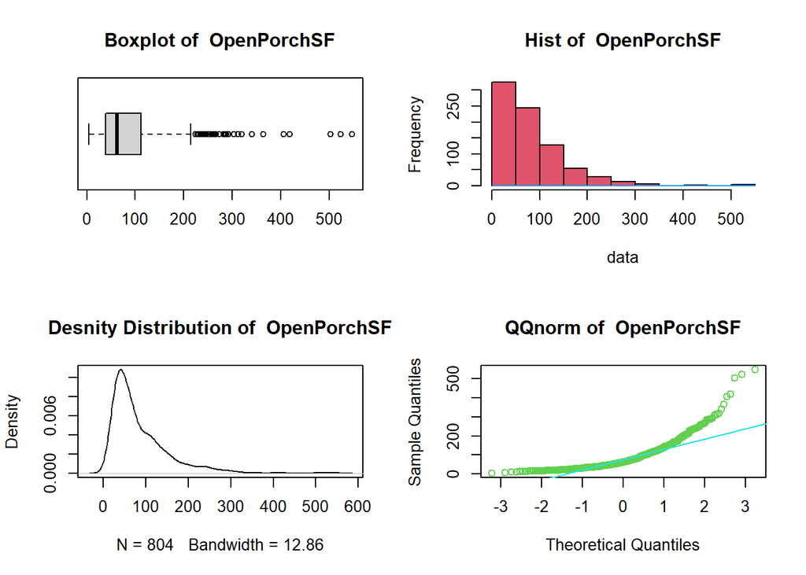

Possiamo dedurre che la distribuzione è positivamente asimetrica e che la maggior parte dei portico aperti sono di area compresa tra 39.00 e 112.00 piedi^2, essendo rispettivamente il 1° e il 3° quantile e con maggior densita alineati alla retta qq della norma. Rimangono ancora degli outlier ## Rimozione

```r
rm_outlier_data = rm_oultiers(rm_0_data,.95)
visualization_continuos(rm_outlier_data, univariate_analysis(rm_outlier_data,"OpenPorchSF"),"OpenPorchSF")
```

```
## $OpenPorchSF
## $OpenPorchSF$Summary
##    Min. 1st Qu.  Median    Mean 3rd Qu.    Max.
##    4.00   38.00   60.00   73.19  102.00  214.00
##
## $OpenPorchSF$Variance
## [1] 2171.49
##
## $OpenPorchSF$Standard_Deviation
## [1] 46.6
##
## $OpenPorchSF$Moda
## $OpenPorchSF$Moda$Mode
## [1] 36
##
## $OpenPorchSF$Moda$Frequency
## [1] 29
```

```
##
## Call:
##  density.default(x = data)
##
## Data: data (761 obs.);   Bandwidth 'bw' = 11.13
##
##        x                y
##  Min.   :-29.38   Min.   :1.243e-06
##  1st Qu.: 39.81   1st Qu.:8.127e-04
##  Median :109.00   Median :2.434e-03
##  Mean   :109.00   Mean   :3.610e-03
##  3rd Qu.:178.19   3rd Qu.:5.164e-03
##  Max.   :247.38   Max.   :1.183e-02
```

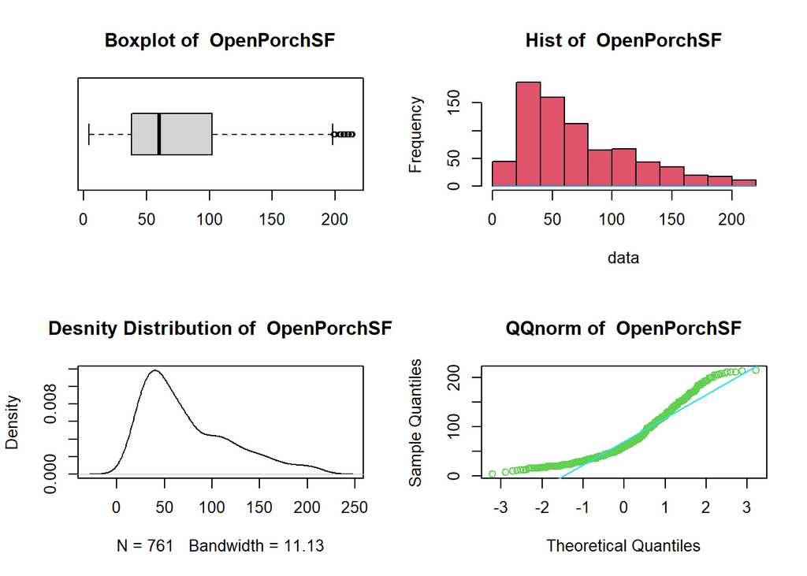

### 27: Visualizazione EnclosedPorch

```r
visualization_continuos(na.omit(House_prices[,"EnclosedPorch"]), sum_info_h[27],"EnclosedPorch")
```

```
## [[1]]
## [[1]]$EnclosedPorch
## [[1]]$EnclosedPorch$Summary
##    Min. 1st Qu.  Median    Mean 3rd Qu.    Max.
##    0.00    0.00    0.00   21.95    0.00  552.00
##
## [[1]]$EnclosedPorch$Variance
## [1] 3735.55
##
## [[1]]$EnclosedPorch$Standard_Deviation
## [1] 61.12
##
## [[1]]$EnclosedPorch$Moda
## [[1]]$EnclosedPorch$Moda$Mode
## [1] 0
##
## [[1]]$EnclosedPorch$Moda$Frequency
## [1] 1252
```

```
##
## Call:
##  density.default(x = data)
##
## Data: data (1460 obs.);  Bandwidth 'bw' = 12.81
##
##        x                y
##  Min.   :-38.43   Min.   :0.000e+00
##  1st Qu.:118.78   1st Qu.:6.346e-06
##  Median :276.00   Median :1.886e-04
##  Mean   :276.00   Mean   :1.587e-03
##  3rd Qu.:433.21   3rd Qu.:6.071e-04
##  Max.   :590.43   Max.   :2.664e-02
```

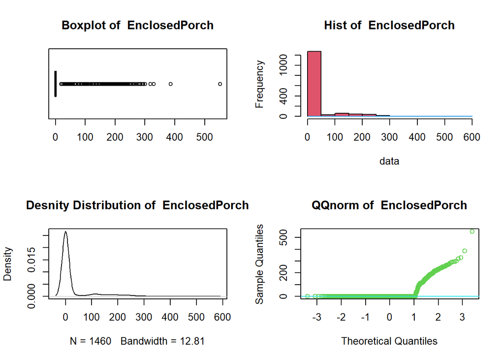

Possiamo dedurre che la distribuzione è positivamente asimetrica. Si puo osservare che l’area del portico chiuso è prelevantemete 0 con 1252 occorrenze qundi non costruitto. Per fare un analisi sui portico chiusi, serve ignorare quelli non ## Rimozione 0

```r
rm_0_data = rm_0(na.omit(House_prices[,"EnclosedPorch"]))
visualization_continuos(rm_0_data, univariate_analysis(rm_0_data,"EnclosedPorch"),"EnclosedPorch")
```

```
## $EnclosedPorch
## $EnclosedPorch$Summary
##    Min. 1st Qu.  Median    Mean 3rd Qu.    Max.
##    19.0   104.2   144.5   154.1   205.0   552.0
##
## $EnclosedPorch$Variance
## [1] 5866.98
##
## $EnclosedPorch$Standard_Deviation
## [1] 76.6
##
## $EnclosedPorch$Moda
## $EnclosedPorch$Moda$Mode
## [1] 112
##
## $EnclosedPorch$Moda$Frequency
## [1] 15
```

```
##
## Call:
##  density.default(x = data)
##
## Data: data (208 obs.);   Bandwidth 'bw' = 23.27
##
##        x                y
##  Min.   :-50.81   Min.   :2.910e-07
##  1st Qu.:117.35   1st Qu.:3.794e-05
##  Median :285.50   Median :3.211e-04
##  Mean   :285.50   Mean   :1.485e-03
##  3rd Qu.:453.65   3rd Qu.:2.944e-03
##  Max.   :621.81   Max.   :5.414e-03
```

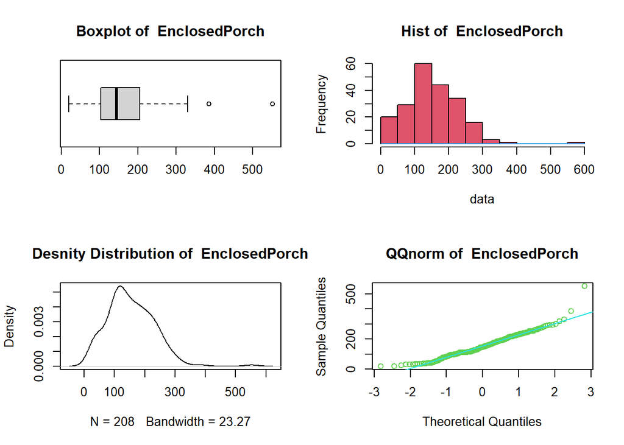

Possiamo dedurre che la distribuzione è positivamente asimetrica e che la maggior parte dei portico chiusi sono di area compresa tra 104.2 e 205.0 piedi^2, essendo rispettivamente il 1° e il 3° quantile e con maggior densita alineati alla retta qq della norma. Rimangono ancora degli outlier ## Rimozione

```r
rm_outlier_data = rm_oultiers(rm_0_data,.95)
visualization_continuos(rm_outlier_data, univariate_analysis(rm_outlier_data,"EnclosedPorch"),"EnclosedPorch")
```

```
## $EnclosedPorch
## $EnclosedPorch$Summary
##    Min. 1st Qu.  Median    Mean 3rd Qu.    Max.
##    19.0   102.0   144.0   149.3   200.5   301.0
##
## $EnclosedPorch$Variance
## [1] 4630.31
##
## $EnclosedPorch$Standard_Deviation
## [1] 68.05
##
## $EnclosedPorch$Moda
## $EnclosedPorch$Moda$Mode
## [1] 112
##
## $EnclosedPorch$Moda$Frequency
## [1] 15
```

```
##
## Call:
##  density.default(x = data)
##
## Data: data (204 obs.);   Bandwidth 'bw' = 21.14
##
##        x                y
##  Min.   :-44.42   Min.   :2.099e-06
##  1st Qu.: 57.79   1st Qu.:5.220e-04
##  Median :160.00   Median :2.447e-03
##  Mean   :160.00   Mean   :2.443e-03
##  3rd Qu.:262.21   3rd Qu.:4.105e-03
##  Max.   :364.42   Max.   :5.684e-03
```

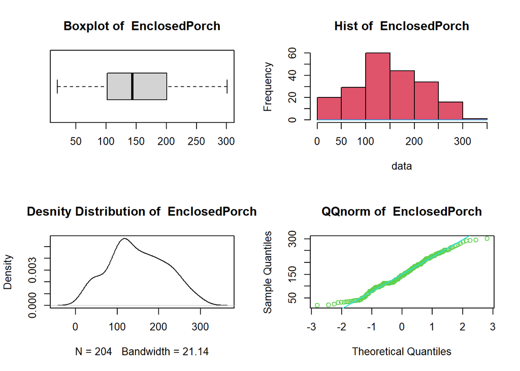

Possiamo notare che la maggior parte dei portico chiusi sono di area compresa tra 102.0 e 200.5 piedi^2, essendo rispettivamente il 1° e il 3° quantile e con maggior densita alineati alla retta qq della norma.

### 28: Visualizazione X3SsnPorch

```r
visualization_continuos(na.omit(House_prices[,"X3SsnPorch"]), sum_info_h[28],"X3SsnPorch")
```

```
## [[1]]
## [[1]]$X3SsnPorch
## [[1]]$X3SsnPorch$Summary
##    Min. 1st Qu.  Median    Mean 3rd Qu.    Max.
##    0.00    0.00    0.00    3.41    0.00  508.00
##
## [[1]]$X3SsnPorch$Variance
## [1] 859.51
##
## [[1]]$X3SsnPorch$Standard_Deviation
## [1] 29.32
##
## [[1]]$X3SsnPorch$Moda
## [[1]]$X3SsnPorch$Moda$Mode
## [1] 0
##
## [[1]]$X3SsnPorch$Moda$Frequency
## [1] 1436
```

```
##
## Call:
##  density.default(x = data)
##
## Data: data (1460 obs.);  Bandwidth 'bw' = 6.145
##
##        x                y
##  Min.   :-18.43   Min.   :0.000e+00
##  1st Qu.:117.78   1st Qu.:1.300e-07
##  Median :254.00   Median :2.019e-05
##  Mean   :254.00   Mean   :1.832e-03
##  3rd Qu.:390.22   3rd Qu.:5.386e-05
##  Max.   :526.43   Max.   :6.356e-02
```

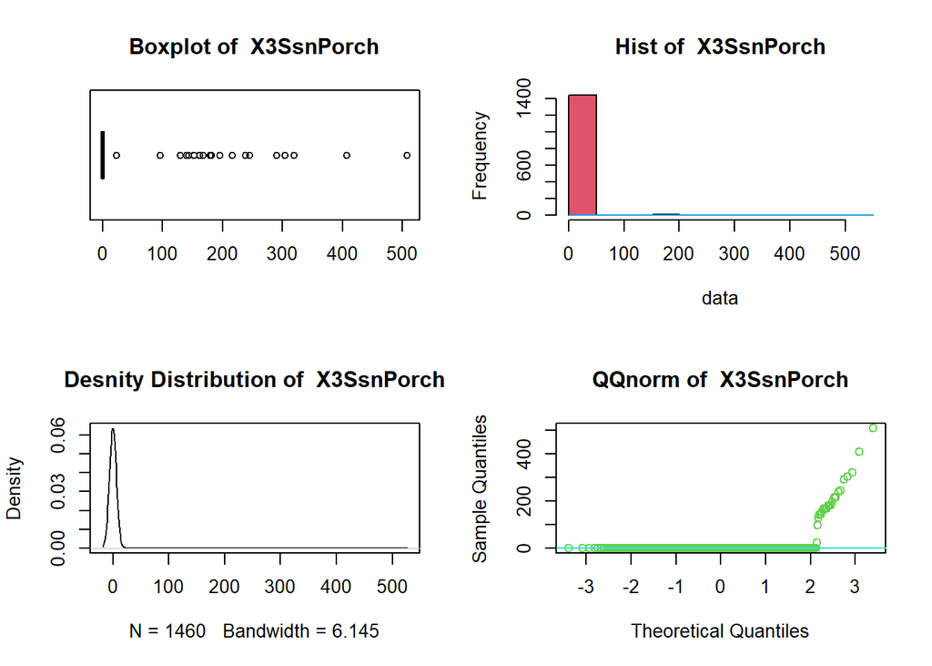

```r
rm_0_data = rm_0(na.omit(House_prices[,"X3SsnPorch"]))
visualization_continuos(rm_0_data, univariate_analysis(rm_0_data,"X3SsnPorch"),"X3SsnPorch")
```

```
## $X3SsnPorch
## $X3SsnPorch$Summary
##    Min. 1st Qu.  Median    Mean 3rd Qu.    Max.
##    23.0   150.8   180.0   207.4   239.8   508.0
##
## $X3SsnPorch$Variance
## [1] 10368.34
##
## $X3SsnPorch$Standard_Deviation
## [1] 101.83
##
## $X3SsnPorch$Moda
## $X3SsnPorch$Moda$Mode
## [1] 168
##
## $X3SsnPorch$Moda$Frequency
## [1] 3
```

```
##
## Call:
##  density.default(x = data)
##
## Data: data (24 obs.);    Bandwidth 'bw' = 31.66
##
##        x                y
##  Min.   :-71.97   Min.   :0.0000059
##  1st Qu.: 96.76   1st Qu.:0.0003565
##  Median :265.50   Median :0.0005635
##  Mean   :265.50   Mean   :0.0014800
##  3rd Qu.:434.24   3rd Qu.:0.0019201
##  Max.   :602.97   Max.   :0.0062139
```

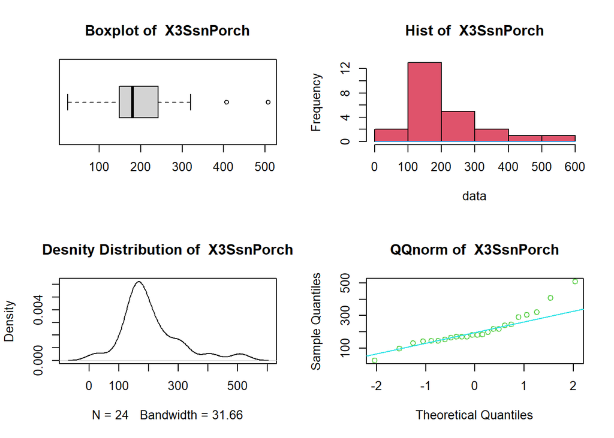

Possiamo dedurre che la distribuzione è positivamente asimetrica e che la maggior parte dei Portico per tre stagioni sono di area compresa tra 150.8 e 239.8 piedi^2, essendo rispettivamente il 1° e il 3° quantile e con maggior densita alineati alla retta qq della norma. Rimangono ancora degli outlier ## Rimozione

```r
rm_outlier_data = rm_oultiers(rm_0_data,.95)
visualization_continuos(rm_outlier_data, univariate_analysis(rm_outlier_data,"X3SsnPorch"),"X3SsnPorch")
```

```
## $X3SsnPorch
## $X3SsnPorch$Summary
##    Min. 1st Qu.  Median    Mean 3rd Qu.    Max.
##    23.0   146.2   174.0   184.7   216.0   320.0
##
## $X3SsnPorch$Variance
## [1] 4615.08
##
## $X3SsnPorch$Standard_Deviation
## [1] 67.93
##
## $X3SsnPorch$Moda
## $X3SsnPorch$Moda$Mode
## [1] 168
##
## $X3SsnPorch$Moda$Frequency
## [1] 3
```

```
##
## Call:
##  density.default(x = data)
##
## Data: data (22 obs.);    Bandwidth 'bw' = 25.25
##
##        x                y
##  Min.   :-52.74   Min.   :8.080e-06
##  1st Qu.: 59.38   1st Qu.:5.392e-04
##  Median :171.50   Median :1.611e-03
##  Mean   :171.50   Mean   :2.227e-03
##  3rd Qu.:283.62   3rd Qu.:3.294e-03
##  Max.   :395.74   Max.   :7.564e-03
```

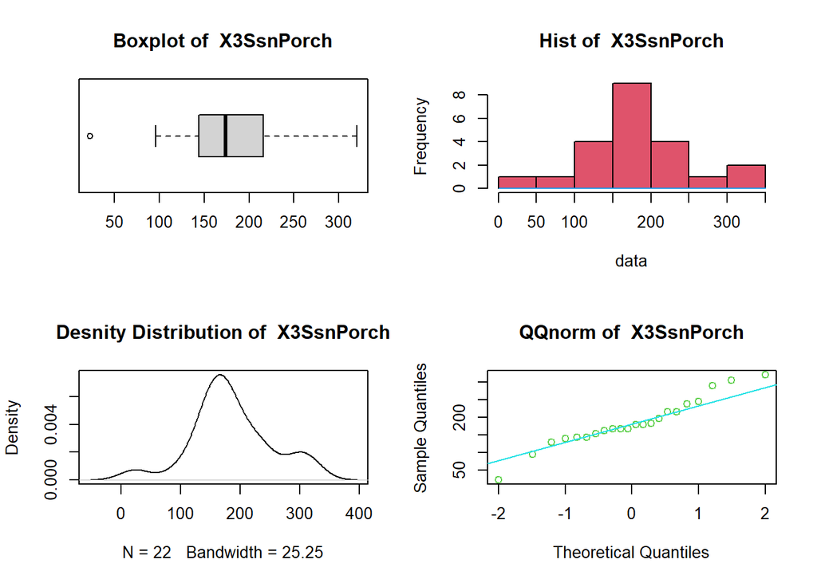

Possiamo notare che la maggior parte dei Portico per tre stagioni sono di area compresa tra 146.2 e 216.0 piedi^2, essendo rispettivamente il 1° e il 3° quantile e con maggior densita alineati alla retta qq della norma.

### 29: Visualizazione ScreenPorch

```r
visualization_continuos(na.omit(House_prices[,"ScreenPorch"]), sum_info_h[29],"ScreenPorch")
```

```
## [[1]]
## [[1]]$ScreenPorch
## [[1]]$ScreenPorch$Summary
##    Min. 1st Qu.  Median    Mean 3rd Qu.    Max.
##    0.00    0.00    0.00   15.06    0.00  480.00
##
## [[1]]$ScreenPorch$Variance
## [1] 3108.89
##
## [[1]]$ScreenPorch$Standard_Deviation
## [1] 55.76
##
## [[1]]$ScreenPorch$Moda
## [[1]]$ScreenPorch$Moda$Mode
## [1] 0
##
## [[1]]$ScreenPorch$Moda$Frequency
## [1] 1344
```

```
##
## Call:
##  density.default(x = data)
##
## Data: data (1460 obs.);  Bandwidth 'bw' = 11.69
##
##        x                y
##  Min.   :-35.06   Min.   :2.640e-07
##  1st Qu.:102.47   1st Qu.:2.890e-05
##  Median :240.00   Median :1.415e-04
##  Mean   :240.00   Mean   :1.814e-03
##  3rd Qu.:377.53   3rd Qu.:4.037e-04
##  Max.   :515.06   Max.   :3.135e-02
```

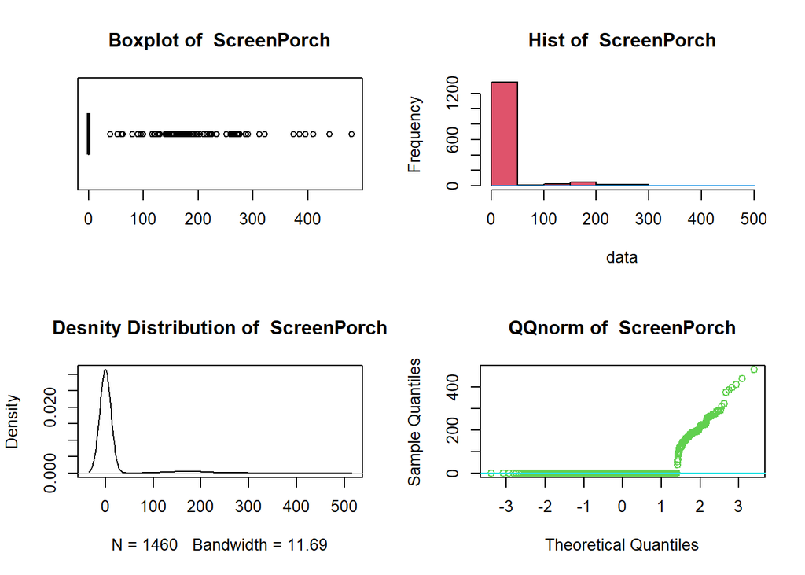

Possiamo dedurre che la distribuzione è positivamente asimetrica. Si puo osservare che l’area del Portico dello schermo è prelevantemete 0 con 1344 occorrenze qundi non costruitto. Per fare un analisi sui Portico dello schermo, serve ignorare quelli non ## Rimozione 0

```r
rm_0_data = rm_0(na.omit(House_prices[,"ScreenPorch"]))
visualization_continuos(rm_0_data, univariate_analysis(rm_0_data,"ScreenPorch"),"ScreenPorch")
```

```
## $ScreenPorch
## $ScreenPorch$Summary
##    Min. 1st Qu.  Median    Mean 3rd Qu.    Max.
##    40.0   143.8   180.0   189.6   224.0   480.0
##
## $ScreenPorch$Variance
## [1] 6076.54
##
## $ScreenPorch$Standard_Deviation
## [1] 77.95
##
## $ScreenPorch$Moda
## $ScreenPorch$Moda$Mode
## [1] 192
##
## $ScreenPorch$Moda$Frequency
## [1] 6
```

```
##
## Call:
##  density.default(x = data)
##
## Data: data (116 obs.);   Bandwidth 'bw' = 20.83
##
##        x                y
##  Min.   :-22.49   Min.   :1.862e-06
##  1st Qu.:118.75   1st Qu.:2.460e-04
##  Median :260.00   Median :5.576e-04
##  Mean   :260.00   Mean   :1.768e-03
##  3rd Qu.:401.25   3rd Qu.:2.672e-03
##  Max.   :542.49   Max.   :6.750e-03
```

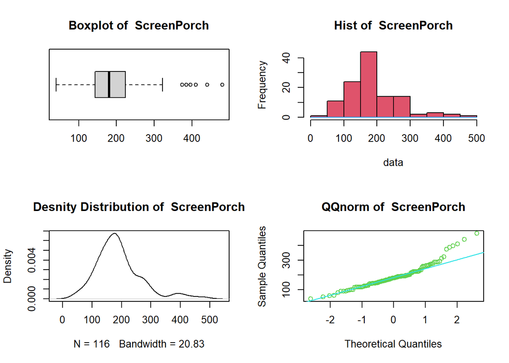

Possiamo dedurre che la distribuzione è positivamente asimetrica e che la maggior parte dei Portico dello schermo stagioni sono di area compresa tra 143.8 e 224.0 piedi^2, essendo rispettivamente il 1° e il 3° quantile e con maggior densita alineati alla retta qq della norma. Rimangono ancora degli outlier ## Rimozione

```r
rm_outlier_data = rm_oultiers(rm_0_data,.95)
visualization_continuos(rm_outlier_data, univariate_analysis(rm_outlier_data,"ScreenPorch"),"ScreenPorch")
```

```
## $ScreenPorch
## $ScreenPorch$Summary
##    Min. 1st Qu.  Median    Mean 3rd Qu.    Max.
##    40.0   142.2   177.0   177.3   214.5   322.0
##
## $ScreenPorch$Variance
## [1] 3410.93
##
## $ScreenPorch$Standard_Deviation
## [1] 58.4
##
## $ScreenPorch$Moda
## $ScreenPorch$Moda$Mode
## [1] 192
##
## $ScreenPorch$Moda$Frequency
## [1] 6
```

```
##
## Call:
##  density.default(x = data)
##
## Data: data (110 obs.);   Bandwidth 'bw' = 18.95
##
##        x                y
##  Min.   :-16.86   Min.   :2.451e-06
##  1st Qu.: 82.07   1st Qu.:4.027e-04
##  Median :181.00   Median :1.985e-03
##  Mean   :181.00   Mean   :2.524e-03
##  3rd Qu.:279.93   3rd Qu.:4.225e-03
##  Max.   :378.86   Max.   :7.267e-03
```

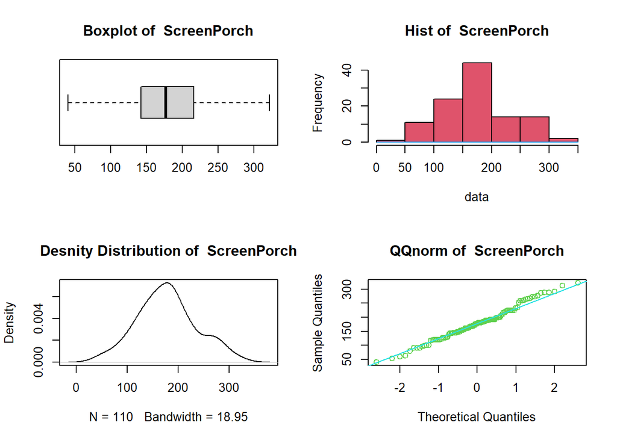

Possiamo notare che la maggior parte dei Portico dello schermo sono di area compresa tra 142.2 e 214.5 piedi^2, essendo rispettivamente il 1° e il 3° quantile e con maggior densita alineati alla retta qq della norma.

### 30: Visualizazione PoolArea

```r
visualization_continuos(na.omit(House_prices[,"PoolArea"]), sum_info_h[30],"PoolArea")
```

```
## [[1]]
## [[1]]$PoolArea
## [[1]]$PoolArea$Summary
##    Min. 1st Qu.  Median    Mean 3rd Qu.    Max.
##   0.000   0.000   0.000   2.759   0.000 738.000
##
## [[1]]$PoolArea$Variance
## [1] 1614.22
##
## [[1]]$PoolArea$Standard_Deviation
## [1] 40.18
##
## [[1]]$PoolArea$Moda
## [[1]]$PoolArea$Moda$Mode
## [1] 0
##
## [[1]]$PoolArea$Moda$Frequency
## [1] 1453
```

```
##
## Call:
##  density.default(x = data)
##
## Data: data (1460 obs.);  Bandwidth 'bw' = 8.421
##
##        x                y
##  Min.   :-25.26   Min.   :0.0000000
##  1st Qu.:171.87   1st Qu.:0.0000000
##  Median :369.00   Median :0.0000000
##  Mean   :369.00   Mean   :0.0012658
##  3rd Qu.:566.13   3rd Qu.:0.0000153
##  Max.   :763.26   Max.   :0.0467836
```

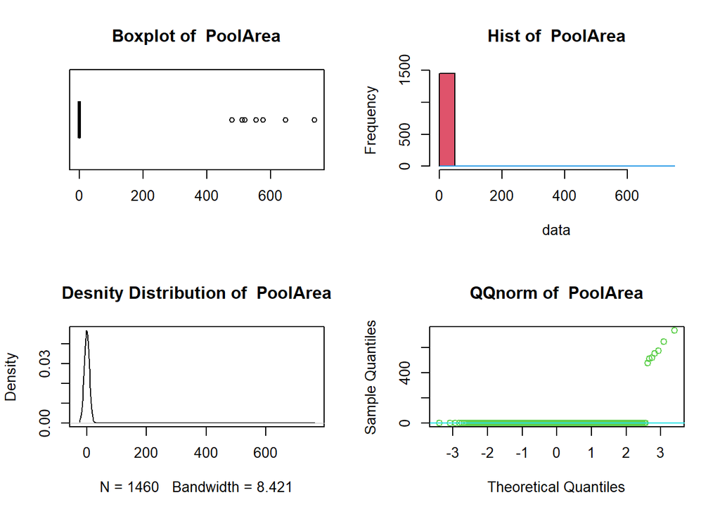

Possiamo dedurre che la distribuzione è positivamente asimetrica. Si puo osservare che l’area della piscina è prelevantemete 0 con 1453 occorrenze qundi non costruitto. Per fare un analisi sulle piscine, serve ignorare quelli non ## Rimozione 0

```r
rm_0_data = rm_0(na.omit(House_prices[,"PoolArea"]))
visualization_continuos(rm_0_data, univariate_analysis(rm_0_data,"PoolArea"),"PoolArea")
```

```
## $PoolArea
## $PoolArea$Summary
##    Min. 1st Qu.  Median    Mean 3rd Qu.    Max.
##   480.0   515.5   555.0   575.4   612.0   738.0
##
## $PoolArea$Variance
## [1] 8071.29
##
## $PoolArea$Standard_Deviation
## [1] 89.84
##
## $PoolArea$Moda
## $PoolArea$Moda$Mode
## [1] 512 648 576 555 480 519 738
##
## $PoolArea$Moda$Frequency
## [1] 1
```

```
##
## Call:
##  density.default(x = data)
##
## Data: data (7 obs.); Bandwidth 'bw' = 43.92
##
##        x               y
##  Min.   :348.2   Min.   :1.456e-05
##  1st Qu.:478.6   1st Qu.:4.850e-04
##  Median :609.0   Median :1.564e-03
##  Mean   :609.0   Mean   :1.915e-03
##  3rd Qu.:739.4   3rd Qu.:3.040e-03
##  Max.   :869.8   Max.   :5.021e-03
```

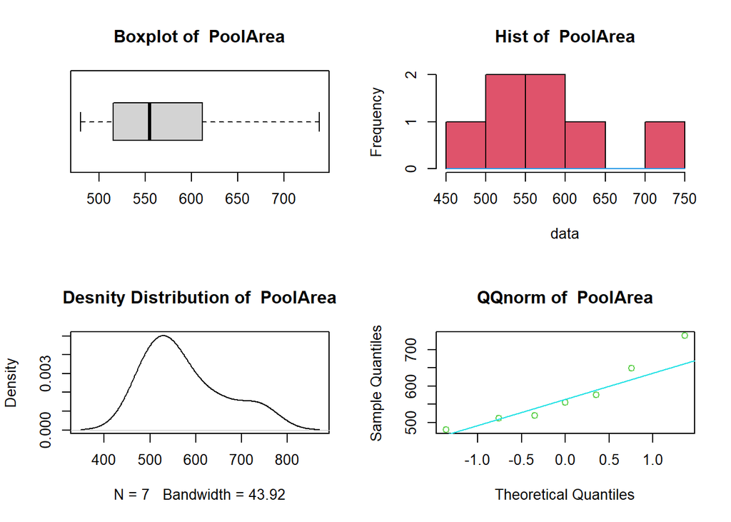

```r
rm_outlier_data = rm_oultiers(rm_0_data,.95)
visualization_continuos(rm_outlier_data, univariate_analysis(rm_outlier_data,"PoolArea"),"PoolArea")
```

```
## $PoolArea
## $PoolArea$Summary
##    Min. 1st Qu.  Median    Mean 3rd Qu.    Max.
##   480.0   515.5   555.0   575.4   612.0   738.0
##
## $PoolArea$Variance
## [1] 8071.29
##
## $PoolArea$Standard_Deviation
## [1] 89.84
##
## $PoolArea$Moda
## $PoolArea$Moda$Mode
## [1] 512 648 576 555 480 519 738
##
## $PoolArea$Moda$Frequency
## [1] 1
```

```
##
## Call:
##  density.default(x = data)
##
## Data: data (7 obs.); Bandwidth 'bw' = 43.92
##
##        x               y
##  Min.   :348.2   Min.   :1.456e-05
##  1st Qu.:478.6   1st Qu.:4.850e-04
##  Median :609.0   Median :1.564e-03
##  Mean   :609.0   Mean   :1.915e-03
##  3rd Qu.:739.4   3rd Qu.:3.040e-03
##  Max.   :869.8   Max.   :5.021e-03
```

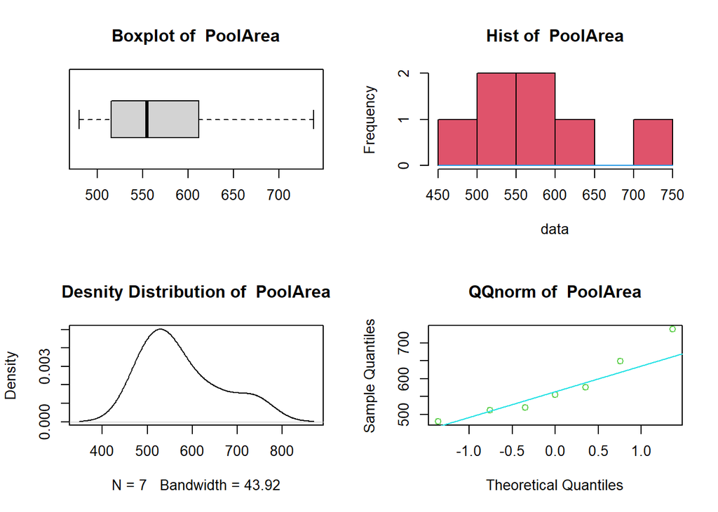

Possiamo notare che la maggior parte delle piscine sono di area compresa tra 515.5 e 612.0 piedi^2, essendo rispettivamente il 1° e il 3° quantile e con maggior densita alineati alla retta qq della norma.

### 31: Visualizazione MiscVal

```r
visualization_continuos(na.omit(House_prices[,"MiscVal"]), sum_info_h[31],"MiscVal")
```

```
## [[1]]
## [[1]]$MiscVal
## [[1]]$MiscVal$Summary
##     Min.  1st Qu.   Median     Mean  3rd Qu.     Max.
##     0.00     0.00     0.00    43.49     0.00 15500.00
##
## [[1]]$MiscVal$Variance
## [1] 246138.1
##
## [[1]]$MiscVal$Standard_Deviation
## [1] 496.12
##
## [[1]]$MiscVal$Moda
## [[1]]$MiscVal$Moda$Mode
## [1] 0
##
## [[1]]$MiscVal$Moda$Frequency
## [1] 1408
```

```
##
## Call:
##  density.default(x = data)
##
## Data: data (1460 obs.);  Bandwidth 'bw' = 104
##
##        x                 y
##  Min.   : -311.9   Min.   :0.000e+00
##  1st Qu.: 3719.0   1st Qu.:0.000e+00
##  Median : 7750.0   Median :0.000e+00
##  Mean   : 7750.0   Mean   :6.210e-05
##  3rd Qu.:11781.0   3rd Qu.:5.010e-07
##  Max.   :15811.9   Max.   :3.682e-03
```

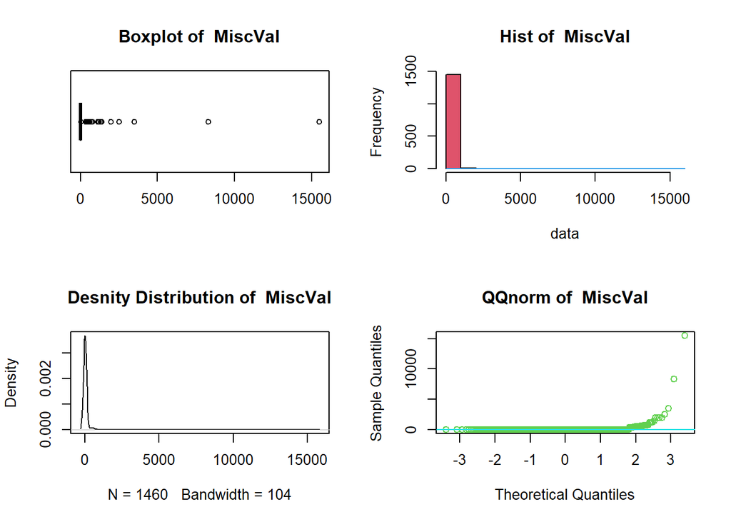

```r
rm_0_data = rm_0(na.omit(House_prices[,"MiscVal"]))
visualization_continuos(rm_0_data, univariate_analysis(rm_0_data,"MiscVal"),"MiscVal")
```

```
## $MiscVal
## $MiscVal$Summary
##    Min. 1st Qu.  Median    Mean 3rd Qu.    Max.
##    54.0   437.5   500.0  1221.0   887.5 15500.0
##
## $MiscVal$Variance
## [1] 5575453
##
## $MiscVal$Standard_Deviation
## [1] 2361.24
##
## $MiscVal$Moda
## $MiscVal$Moda$Mode
## [1] 400
##
## $MiscVal$Moda$Frequency
## [1] 11
```

```
##
## Call:
##  density.default(x = data)
##
## Data: data (52 obs.);    Bandwidth 'bw' = 137.1
##
##        x                 y
##  Min.   : -357.4   Min.   :0.000e+00
##  1st Qu.: 3709.8   1st Qu.:0.000e+00
##  Median : 7777.0   Median :0.000e+00
##  Mean   : 7777.0   Mean   :6.137e-05
##  3rd Qu.:11844.2   3rd Qu.:1.989e-05
##  Max.   :15911.4   Max.   :1.626e-03
```

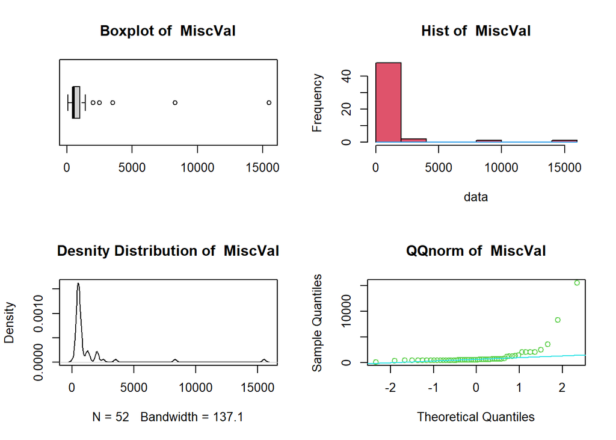

### 32: Visualizazione MoSold

```r
visualization_discrete(na.omit(House_prices[,"MoSold"]), sum_info_h[32],"MoSold")
```

```
## [[1]]
## [[1]]$MoSold
## [[1]]$MoSold$Summary
##    Min. 1st Qu.  Median    Mean 3rd Qu.    Max.
##   1.000   5.000   6.000   6.322   8.000  12.000
##
## [[1]]$MoSold$Variance
## [1] 7.31
##
## [[1]]$MoSold$Standard_Deviation
## [1] 2.7
##
## [[1]]$MoSold$Moda
## [[1]]$MoSold$Moda$Mode
## [1] 6
##
## [[1]]$MoSold$Moda$Frequency
## [1] 253
##
##
##
##
## [1] "freq: "
##
## data
##   1   2   3   4   5   6   7   8   9  10  11  12
##  58  52 106 141 204 253 234 122  63  89  79  59
##
## [1] "percintile: "
##
## data
##         1         2         3         4         5         6         7         8
##  3.972603  3.561644  7.260274  9.657534 13.972603 17.328767 16.027397  8.356164
##         9        10        11        12
##  4.315068  6.095890  5.410959  4.041096
```

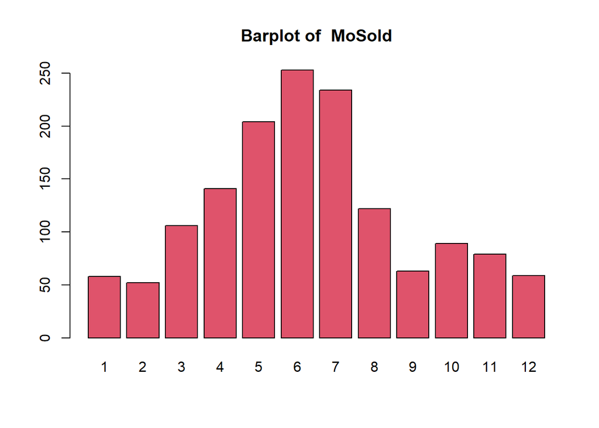

# Descrete Possiamo notare che i mesi con le moggior vendute sono fra il 5 e 8 mese con8 ~=55.69% Dal 1 si ha una crescita di vendute fino al 6 mese dove si il massimo di vendite con 253 vendite dopodicche la vendita decresce

### 33: Visualizazione YrSold

```r
visualization_discrete(na.omit(House_prices[,"YrSold"]), sum_info_h[33],"YrSold")
```

```
## [[1]]
## [[1]]$YrSold
## [[1]]$YrSold$Summary
##    Min. 1st Qu.  Median    Mean 3rd Qu.    Max.
##    2006    2007    2008    2008    2009    2010
##
## [[1]]$YrSold$Variance
## [1] 1.76
##
## [[1]]$YrSold$Standard_Deviation
## [1] 1.33
##
## [[1]]$YrSold$Moda
## [[1]]$YrSold$Moda$Mode
## [1] 2009
##
## [[1]]$YrSold$Moda$Frequency
## [1] 338
##
##
##
##
## [1] "freq: "
##
## data
## 2006 2007 2008 2009 2010
##  314  329  304  338  175
##
## [1] "percintile: "
##
## data
##     2006     2007     2008     2009     2010
## 21.50685 22.53425 20.82192 23.15068 11.98630
```

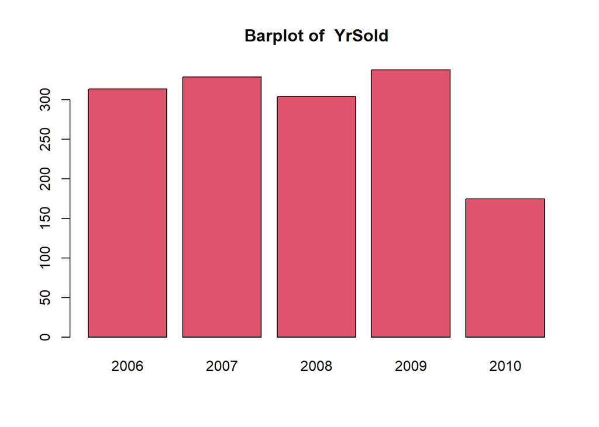

# Descrete Si puo notare che la vendita per anno dal 2006 a 2009 e per lo piu uniforme con l’anno di maggior vendita nel 2009 con 338 venidite Nel 2010 invece si ha il minimo di vendite con 175 vendite

### 34: Visualizazione SalePrice

```r
visualization_continuos(na.omit(House_prices[,"SalePrice"]), sum_info_h[34],"SalePrice")
```

```
## [[1]]
## [[1]]$SalePrice
## [[1]]$SalePrice$Summary
##    Min. 1st Qu.  Median    Mean 3rd Qu.    Max.
##   34900  129975  163000  180921  214000  755000
##
## [[1]]$SalePrice$Variance
## [1] 6311111264
##
## [[1]]$SalePrice$Standard_Deviation
## [1] 79442.5
##
## [[1]]$SalePrice$Moda
## [[1]]$SalePrice$Moda$Mode
## [1] 140000
##
## [[1]]$SalePrice$Moda$Frequency
## [1] 20
```

```
##
## Call:
##  density.default(x = data)
##
## Data: data (1460 obs.);  Bandwidth 'bw' = 1.314e+04
##
##        x                y
##  Min.   : -4527   Min.   :1.000e-12
##  1st Qu.:195211   1st Qu.:2.700e-08
##  Median :394950   Median :1.687e-07
##  Mean   :394950   Mean   :1.250e-06
##  3rd Qu.:594689   3rd Qu.:1.535e-06
##  Max.   :794427   Max.   :7.682e-06
```

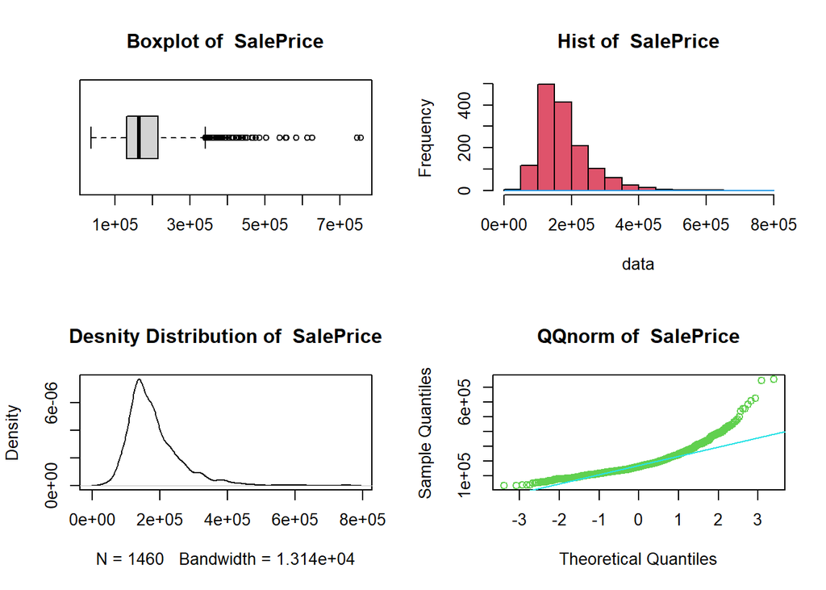

Possiamo dedurre che la distribuzione è positivamente asimetrica e che la maggior parte del prezzo di vendita è compresa tra 129975 e 214000, essendo rispettivamente il 1° e il 3° quantile e con maggior densita alineati alla retta qq della norma. Rimangono ancora degli outlier ## Rimozione

```r
rm_outlier_data = rm_oultiers(na.omit(House_prices[,"SalePrice"]),.95)
visualization_continuos(rm_outlier_data, univariate_analysis(rm_outlier_data,"PoolArea"),"PoolArea")
```

```
## $PoolArea
## $PoolArea$Summary
##    Min. 1st Qu.  Median    Mean 3rd Qu.    Max.
##   34900  128963  159217  169632  202624  336000
##
## $PoolArea$Variance
## [1] 3418381382
##
## $PoolArea$Standard_Deviation
## [1] 58466.93
##
## $PoolArea$Moda
## $PoolArea$Moda$Mode
## [1] 140000
##
## $PoolArea$Moda$Frequency
## [1] 20
```

```
##
## Call:
##  density.default(x = data)
##
## Data: data (1394 obs.);  Bandwidth 'bw' = 1.163e+04
##
##        x                  y
##  Min.   :    14.5   Min.   :8.080e-10
##  1st Qu.: 92732.2   1st Qu.:5.100e-07
##  Median :185450.0   Median :1.865e-06
##  Mean   :185450.0   Mean   :2.694e-06
##  3rd Qu.:278167.8   3rd Qu.:4.397e-06
##  Max.   :370885.5   Max.   :8.246e-06
```

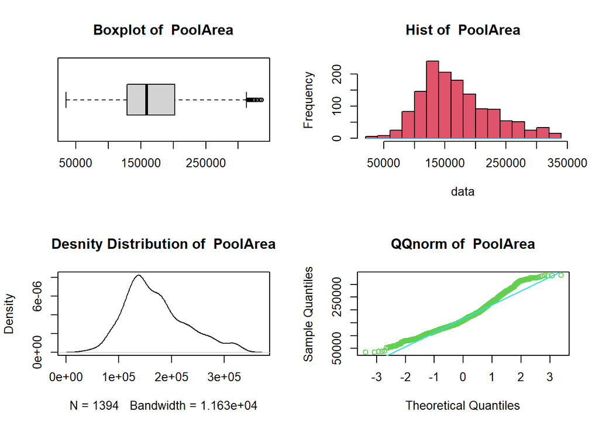